# USP537 Problem Sets

Shen Qu

Winter 2019

## Problem Set 1

1. Portland’s transit agency TriMet wants to increase transit usage by 15%. They expect no changes in the demand for transit and will lower the fare to attract the additional riders. The estimated price elasticity of demand is 0.3(actual elasticity used by TriMet).
1. Calculate the percentage change necessary in fares to achieve the increased transit usage and the change in fare box revenue (use simple percentages rather than the midpoint elasticities).

When no changes in the demand for transit, the value of usage moves along the MD curve, then

$$\text{Elasticity }\eta=\frac{\Delta Q/Q}{\Delta P/P}\implies\Delta P/P=\frac{\Delta Q/Q}{\eta}=\frac{0.15}{0.3}=50\%$$
$$TR=50\%P(1+15\%)Q=57.5\%PQ$$

50% decrease in fares could achive the increase transit usage by 15%. The new revenue will be 57.5% of previous revenue.

2. Would you expect the long-run price elasticity of demand to be larger or smaller? Explain why?

I expect the long-run price elasticity of demand to be larger. Demand tends to be more elastic in the long rung rather than in the short run, because when prices change consumers often need more time to respond and change their shopping habits such as househould or firms’ location, vehicle ownership, further change travel behaviors. (Mankiw, 2004).

- Reference

*Mankiw (2004) “Principals of Macroeconomics”,South-WesternCollegePub,UK*

3. Do you expect that costs will rise? Consider total cost, fixed cost, and variable cost. Explain why it would or would not.

If the extra riderships don’t exceed current transit capacity, fixed cost would not change. The variable cost will rise for the addtional operation cost such as energy consumption and labor cost. Thus, the total cost would increase. If current transit is underload, the change would be tiny.

2. In “The Urban Transportation Problem: A Reexamination and Update”, by John F. Kain([GTW] Chap11), the author concludes the paper with a recommendation: “There remains a strong, if not compelling, case to begin charging road users the full social cost of their road use, for reversing the public ownership and operation of transit services, and for stopping wasteful expenditures on ineffective rail systems.” Please write a short analysis (approximately1 page, single-spaced, typed) highlighting your arguments either in support of or against this recommendation.

There are three points in Kain’s statement: charging road users the full social cost, reversing public ownership and operation of transit services, and stopping ineffective rail systems (Kain, 2001 p.396). The three concepts are related. In general, I agree with him and try to make a further discussion.

- Charging road users the full social cost

The principle of road pricing is to balance the cost and externality. Because the road using costs do not reflect true costs to society and environment, users are not paying the full costs of their purchases and even unaware of it. They will tend to use too much that is subsidized by society. The markets are distorted and inefficient.

Road user charges have two functions. The first one is used for revenue generation, which was used to road infrastructure financing. The second function is as a transportation demand management tool, which can reduce peak hour travel, release traffic congestion, and encourage transit development. Kain (2001) believes the later: “In the short run, motorists would make fewer trips, change their time of travel, and alter their destinations…In the long run, higher road user charges would eventually affect the dispersed patterns of workplaces and residences that were in part induced by congestion” (P.393).

The problem is how to get “the right price”? Prices should reflect all the costs and externalities including both negative and positive. Many economists try to measure the lost such as congestion, air pollution, GHG emissions, visual intrusion, noise, and road accidents. But “economists disagree over how to set tolls, how to cover common costs, what to do with any excess revenues, whether and how”losers" from tolling previously free roads should be compensated, and whether to privatize highways. It is hard to measure the benefit of road using such as economic growth, the communication of information and technology, the recreation activities, and the emotional need for social lives. Kain’s main idea is charging low-occupancy vehicles and subsidizing transit (p.393). It is also a huge challenge at the operating level, which leads to the second topic: privatization.

The application of congestion charges is currently limited to a small number of cities and urban roads. The technology of electronic road pricing through ITS is making detailed billing based on actual use feasible and affordable.

- Reversing public ownership and operation of transit services

Transit is a quasi-public good, Off-peak travelers’ consumption does not reduce any other’s consumption of that good. In some time or location, transit is scarce goods. Both excludability and rivalry are possible. Hart (1995) proposes the party with the better investment technology should be the owner , while Besley and Ghatak (2001) argue that the party who has a larger valuation for the public good should be the owner. Klein, Moore and Reja (1997) point out public transit authorities have tended to over-provide their service. (P.12). It seems that privatization can help to improve efficiency and achieve benefit maximum inside the transportation system, promote the resources redistribution by the hand of market. But Market cannot solute the problem of externalities by itself. The free travel and dispersed patterns might become the wealthy’s privilege. For transit, the scarce time and segments will turn to “club goods,” which means high excludability and low rivalry in consumption. In social justice or equality, the public department still needs to provide alternative goods or subsidies. Especially, mass transit, what is commonly known as natural monopolies, need huge initial investment and have essentially zero marginal costs. It beyond the issues of ownership or operation.

- The ineffective rail systems

Kain (2001) believes busway can close match between demand and capacity with the lower operating costs, (P.379). “Research on mode choice shows that travelers value the following characteristics: short trip times, avoidance of transfers and waiting time, door-to-door service, reliability, comfort, seat availability, storage space, security, and flexibility” (Klein, Moore and Reja, 1997. P.9). In this way, rail system is the most expensive and least flexible, should be stopped.

Other reasons Kain gave are disappointing ridership than projected (p.362), the dispersed employment patterns and low population densities (P.366). It is true that the low density in the U.S. make transit operators difficult to provide competitive services. Meaning while, in some cities with mid-high income and high density such as New York and Hong Kong, a powerful rail system support the cities operation and play an irreplaceable role (Pushkarev and Zupan,1997; Cervero,1998).

Review the history, “the steady rise in auto ownership and declines in transit use since 1895 were largely efficient responses to changes in technology and rising incomes” (Kain, 2001. P.359). “The transit market is contracting because of natural forces” (Klein, Moore and Reja, 1997. P.16). Therefore, we should be careful when planning a rail in a med-low density area and have to pay the heavy cost of rail system in some cities. Beside advocating BRT and TOD in middle cities or growing area, next generation of technology such as automated driving system could turn the trend in future and lead to an unpredictable land use pattern.

- Reference

*[1] Kain, John F. (2001). Essays in transportation economics and policy : a handbook in honor of john r. meyer, Chapter 11. Brookings Institution Press.*

*[2] Paul Johnson, Andrew Leicester & George Stoye. (2012). Fuel for Thought – The what, why and how of motoring taxation. Institute for Fiscal Studies and Royal Automobile Club Foundation for Motoring. Executive Summary, pp. v.*

*[3] Lindsey, Robin. (2006). Do Economists Reach a Conclusion on Road Pricing? The Intellectual History of an Idea. Econ Journal Watch. 3 (2): 292–379.*

*[4] Small, Kenneth A.; Verhoef, Erik T. (2007). The Economics of Urban Transportation. Routledge, New York. pp. 148–153.*

*[5] Demsetz, Harold. (1970). Full Access The Private Production of Public Goods. Journal of Law and Economics. 13 (2): 293–306.*

*[6] Hart, Oliver. (1995). Firms, Contracts, and Financial Structure. Oxford University Press.*

*[7] Besley, Timothy; Ghatak, Maitreesh. (2001). Government Versus Private Ownership of Public Goods. The Quarterly Journal of Economics. 116 (4): 1343–72.*

*[8] Klein, D. B., Moore, A. T., & Reja, B. (1997). Curb rights: a foundation for free enterprise in urban transit. Brookings Institution Press.*

3. Rail City operates a train service on weekdays only. The fixed cost is $120,000 per day. The operating cost is $100 per train-hour, with service adjusted to provide 200 rides per train-hour. This yields a marginal cost of $0.50 per rider. Use this where information on marginal cost is needed. The following information is available regarding cost and demand on a daily basis.

|  | Cost | Revenue | Demand |
| --- | --- | --- | --- |
| Fixed | $FC=\$120000$ |  |  |
| Marginal | $MC=0.5$ | $MR=10-0.0002Q$ | $P=\$10-0.0001Q$ |
| Total | $TC=FC+VC=\$120000+0.5Q$ | $TR=P\times Q=10Q-0.0001Q^2$ |  |

1. What number of riders will use the system if the price is set equal to marginal cost(This is essentially equivalent to assuming that a benevolent social planner sets the price so that maximum efficiency is reached)? How much service will be provided (Q*)? What are the subsidies or profits at this level of cost and price? What is the consumer surplus?

Let $P^*=MC$, then $10-0.0001Q^*=0.5\implies Q^*=95000$ riders. The service is $95000/200=475$ train-hour.

$TR-TC=(P^*Q^*)–(120000+P^*Q^*)=-\$120000$

$CS^*= \frac12(10-P^*)Q^*=\frac12\times(10-0.5)\times95000=\$451250$

When the price equals marginal cost, there will be 95000 riders and 475 train-hour service will be provided.It needs $120000 subsidies for operation. The consumer surplus reach the maximum $451250.

2. If the price is raised to $2.00, how many people will use the train, and what happens to total revenue? What subsidy is required? Calculate any efficiency loss or gain associated with this change. Compare the change in subsidy with the change in consumer surplus.

When $P_2=\$2.00$, there will be $Q_2=\frac{10-2}{0.0001}=80000$ riders.

$TR=P_2Q_2=2\times80000=\$160000$.

$TR-TC=160000–(120000+0.5\times8000)=\$0$, $\Delta(TR-TC)=0-(-120000)=\$120000$

$CS=\frac12(10-P_2)Q_2=\frac12(10-2)80000=320000$, $\Delta{CS}=320000-451250=-\$131250$

$PS=(P_2-P^*)Q_2=(2-0.5)80000=120000$

$TS=CS+PS=320000+120000=440000$

$DWL=\frac12\Delta P\Delta Q=\frac12(2.0-0.5)(80000-95000)=-\$11250$

When the price equals to $2, there are 80000 riders. The total revenue is $160000 and don’t need subsidies. But the consumer surplus loss $131250, which is greater than the decrease in subsidies $120000. It means we should not raise price for reducing subsidies.

3. Suppose that a monopolist is allowed to run the system and set price. What quantity ($Q_m$) and price ($P_m$) will be set and what profits or losses will be generated if the monopolist wants to maximize profits? Calculate any efficiency loss associated with this level of service.

When $MR=MC$, the monopolist maximizes profits. $10–0.0002Q_m=0.5\implies Q_m=47500$ riders, $P_m=10–0.0001Q=10–4.75=\$5.25$

$TR-TC=(P_m-P^*)Q_m-FC=(5.25-0.5)\times47500–120000=\$105625$

$CS=\frac12(10-P_m)Q_m=\frac12(10-5.25)47500=112812.5$

$PS=(P_m-P^*)Q_m=(5.25-0.5)47500=225625$

$TS=CS+PS=112812.5+225625=338437.5$

$DWL=\frac12\Delta P\Delta Q=\frac12(5.25-0.5)(47500-95000)=-\$112812.5$

When the marginal revenue equals marginal cost, the price is $5.25 and riders are 47500. The monopolist get the maximum profit of $105625. However, the total efficientcy lost are $112812.5. We should not sacrific the publis interest for maximizing the monopolist’s profit.

4. Could the monopolist make a profit if fixed costs are $250,000 per day? Does this mean that it would be a mistake to build the train based on economic benefits and costs for this level of fixed cost? Explain why you think it would or would not be from an economic efficiency perspective and include appropriate calculations.

Let $FC=\$250000$, the monopolist’s maximum profit is $TR-VC-FC=(P_m-P^*)Q_m-250000=-\$24375$.

The monopolist won’t make a profit. To examine the efficiency, we should compare subsidies and cunsumer surplus.

If the price is set to $P^*=0.5$, the social benefit is $CS+TR-TC=451250+(0.5-0.5)95000-250000=\$201250$

If the price is set to $P_m=5.25$, the social benefit is $CS+TR-TC=112812.5-24375=\$88437.5$

Let $TS+TR-TC=\frac12(10+P-2P^*)Q-250000=-0.00005Q^2+9.5Q–250000=0$, $Q_{1,2}=\frac{-b\pm \sqrt{b^2-4ac}}{2a}=\frac{9.5\pm\sqrt{40.25}}{0.0001}$, $Q_1=31558,Q_2=158442$. For $Q\le95000$, so $Q=31557.11,P=6.844289$.

Then $CS+TR-TC=49792.56-49792.57=\$0$. Once the price is lower than $6.844289, the riders are more than 31558, the cunsumer surplus will be larger than subsidies.

The reults prove that the train is worth to be bulit because social benefit are positive rather than considering the profit of monopolist. Only if the riders are less than 31558, building this train is a mistake for a negative social benefit.

| P($) | Rider | Fixed Cost | Variable Cost | Total Cost |  | Revenue | subsidies/profit |  | Consumer Surplus | Producer Surplus | Total Surplus | DWL |
| --- | --- | --- | --- | --- | --- | --- | --- | --- | --- | --- | --- | --- |
| $P$ | $Q$ | $FC$ | $P^*Q$ | $FC+VC$ |  | $PQ$ | $(P-P^*)Q-FC$ |  | $\frac12(10-P)Q$ | $(P-P^*)Q$ | $\frac12(10+P-2P^*)Q$ | $\frac12\Delta P\Delta Q$ |
| 0.50 | 95000 | 120000 | 47500 | 167500 |  | 47500 | -120000 |  | 451250 | 0 | 451250 | 0 |
| 2.00 | 80000 | 120000 | 40000 | 160000 |  | 160000 | 0 |  | 320000 | 120000 | 440000 | -11250 |
| 5.25 | 47500 | 120000 | 23750 | 143750 |  | 249375 | 105625 |  | 112812.5 | 225625 | 338437.5 | -112812.5 |
| 0.50 | 95000 | 250000 | 47500 | 297500 |  | 47500 | -250000 |  | 451250 | 0 | 451250 | 0 |
| 5.25 | 47500 | 250000 | 23750 | 273750 |  | 249375 | -24375 |  | 112812.5 | 225625 | 338437.5 | -112812.5 |
| 6.84 | 31558 | 250000 | 15779 | 265779 |  | 215986 | -49792.57 |  | 49792.56 | 200207.4 | 250000 | -201250 |

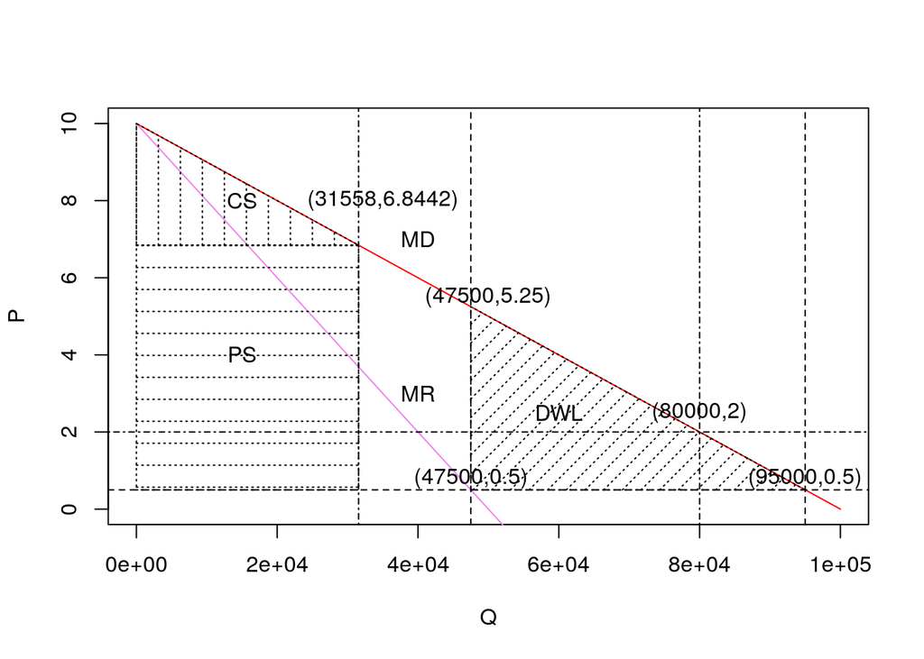

## Problem Set 2

1. Elasticities and Consumer Surplus

In April of 1973, the Massachusetts Bay Transportation Authority (MBTA) initiated an experiment called “Dime Time.”(See attached article) On weekdays between the hours of 10am and 3pm, the fare for travel on the MBTA’s rail lines was reduced from 25 cents to 10 cents, but was 25 cents during all other hours. During the “Dime Time” experiment, which lasted until August1975, fares for bus travel remained at 20 cents per ride during all hours. The “Dime Time” experiment provided an unusual opportunity to evaluate the sensitivity of midday rail transit demand to a reduction in fare, a subject of interest to many transit operators and planners.Please use the mid-point method for all of your elasticity calculations.

Table 1: Average weekday MBTA rail transit passengers between 10am and 3pm with “Dime Time”, by previous mode of travel and income class

|  | income class |  |  |  |
| --- | --- | --- | --- | --- |
| Previous travel mode | Low | Moderate | high | total |
| MBTA rail transit |  |  |  |  |
| 7am - 10 am | 370 | 215 | 175 | 760 |
| 10 am - 3 pm | 9500 | 8250 | 5100 | 22850 |
| 3 pm - 6 pm | 255 | 165 | 135 | 555 |
| MBTA bus transit | 1080 | 680 | 340 | 2100 |
| Private automobile |  |  |  |  |
| driver | 895 | 525 | 400 | 1820 |
| passenger | 220 | 75 | 80 | 375 |
| walk | 850 | 380 | 90 | 1320 |
| no previous trip | 1850 | 570 | 90 | 2510 |
| Toatal | 15020 | 10860 | 6410 | 32290 |

Note on interpretation of this table: This table shows the average number of people who traveled via rail between 10am and 3pm during the “Dime Time” experiment. The different categories tell us what mode these people used before switching to rail. So, for example, we know that the total number of people riding the rail system during off-peak hours under “Dime Time” was 32,290. Of these 32,290, 22,850 passengers rode during these hours before the lower fare was introduced. 2,100 of the 32,290 previously rode the bus, but switched over to rapid transit with the new lower fare.

1. Using the data provided in Table 1, estimate the fare elasticity of total weekday demand for MBTA rail transit service during midday (10am-3pm).

$$\text{Elasticity }\eta=\frac{\Delta Q/Q}{\Delta P/P}=\frac{\frac{32290-22850}{(32290+22850)/2}}{\frac{0.1-0.25}{(0.1+0.25)/2}}=-0.399468$$

The fare elasticity of total weekday demand for MBTA rail transit service during midday (10am-3pm) is -0.399468.

2. According to this elasticity estimate, is the demand for midday rail transit service elastic or inelastic? Comment on your answer.

For $-0.399468\in(-1,1)$, the demand for midday rail transit service is inelastic. The result shows that the ridership will decrease -0.399468% when fare has 1% increase, which indicates that the consumers are not sensitive with fare change.

3. How does the elasticity of demand for midday rail transit service vary among the three income groups (low, moderate, and high) for which ridership data are reported inTable 1? Comment onthese variations.

$$\eta_{Low}=\frac{\Delta Q/Q}{\Delta P/P}=\frac{\frac{15020-9500}{(15020+9500)/2}}{\frac{0.1-0.25}{(0.1+0.25)/2}}=-0.5252855$$

$$\eta_{Mid}=\frac{\Delta Q/Q}{\Delta P/P}=\frac{\frac{10860-8250}{10860+8250}}{\frac{0.1-0.25}{(0.1+0.25)/2}}=-0.3186813$$

$$\eta_{Mid}=\frac{\Delta Q/Q}{\Delta P/P}=\frac{\frac{6410-5100}{(6410+5100)/2}}{\frac{0.1-0.25}{(0.1+0.25)/2}}=-0.2655662$$

The results show a negative relation between income group and absolute value of fare elasiticity of demand. The higher income group has lower absolute value of elasiticity which is closer to 0. It indicates the low income group is more sensitive to the change of fare.

I also find the mean value of elasiticities is -0.3698443, which is larger than the overall elasticity. This result suggests that we may use different grouping methods to examine the data. If possible, using the value of income as a continue explainatory variable may be interesting.

4. Table 1 also reports the prior behavior of MBTA rail transit passengers traveling during “Dime Time” hours. Boston’s regional transportation planning agency estimated that 233,760 auto trips (including both driver and passenger trips) were made in the MBTA service area on a typical weekday before the “Dime Time” program began. From these data, estimate the cross elasticity of demand for auto travel with respect to fare for midday rail transit trips. How do you interpret the arithmetic sign of this elasticity?

$$\eta_{Cross}=\frac{\Delta Q_{Auto}/Q_{Auto}}{\Delta P_{Rail}/P_{Rail}}=\frac{\frac{-1820-375}{233760}}{\frac{0.1-0.25}{(0.1+0.25)/2}}=0.01095497$$

The result shows a positve cross elasticity of demand, which prove auto trips and rail transit trips are substitute goods. The absolue value of cross elasticity is very close to 0 whcih indicate the number of auto users is very inelasitic with fare for rail transit. Each percent decrease of fare for transit only brings 0.01095497% decrease in number of auto trips.

5. The MBTA estimated that prior to the “Dime Time” experiment, average weekday travel on the rail service during peak periods (7-10am and 3-6pm) was 203,670 passengers. Estimate the cross-elasticity of demand for peak-period rail travel with respect to the off-peak rail fare.

$$\eta_{Cross}=\frac{\Delta Q_{Peak}/Q_{Peak}}{\Delta P_{Off}/P_{Off}}=\frac{\frac{-760-555}{203670}}{\frac{0.1-0.25}{(0.1+0.25)/2}}=0.00753261$$

The result shows a positve cross elasticity of demand, which prove peak-period rail trips and off-peak trips are substitute goods. The absolue value of cross elasticity is closer to 0 than that of auto trips whcih indicate the number of peak-period tirps is very inelasitic with fare for rail transit. Each percent decrease of fare for transit only brings 0.00753261% decrease in number of peak-period rail trips. It can be explain that commuting trips are not sensitive to the change of off-peak fare.

6. Please draw a demand curve and answer the following questions using the diagram:

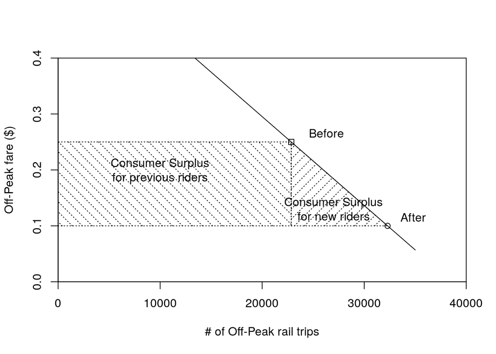

1. Label the area of total daily benefits to off-peak riders, as measured by the increase in consumer surplus, of the “Dime Time” experiment?

The whole shadow areas represent the increse in off-peak consumer surplus, which equal $\frac12(22850+32290)\times(0.25-0.1)=4135.5$

2. Label how much of the increase in consumer surplus represented fare savings to passengers who already traveled on the rail system during the midday at the initial fare?

The left shadow area represents the increse in consumer surplus for previous passengers during the midday, which equals $22850\times(0.25-0.1)=3427.5$

3. Describe verbally how were the benefits in (ii) divided among riders in the three income groups?

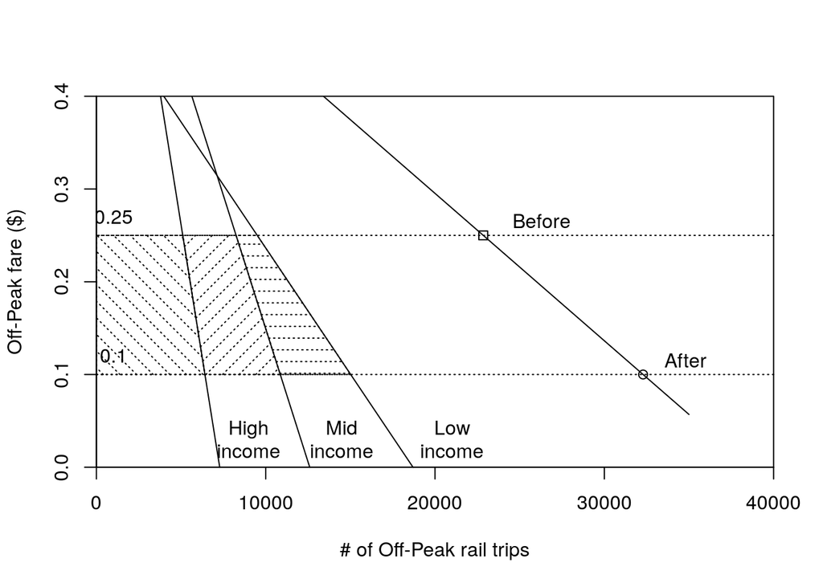

|  | previous consumer surplus | new consumer surplus | total surplus |
| --- | --- | --- | --- |
| Low income | 1425 | 414 | 1839 |
| Mid income | 1237.5 | 195.75 | 1433.25 |
| High income | 765 | 98.25 | 863.25 |
| Total | 3427.5 | 708 | 4135.5 |

The fare saving to passengers who already traveled on the rail transit are divided to 3 parts: 41.57549% (low income group); 36.10503% (mid income group); 22.31947% (high income group).

4. Why is it important to distinguish between consumer benefits to passengers who had beenusing the rail system at the higher fare and those received by new riders who beganto use the system inresponse to the fare change?

The purpose of subsidies is to encourage more transit trips. The effect of reduction in fare by MBTA should be measured by the number of new passengers, who changed their travel behavior.

2. Using an aggregate demand model

Lee’s 1980 study of gasoline demand in California yielded the following estimation results: (dependent variable is 1000s gallons of gasoline $R^2=0.92$).

| Explanatory Variable | Constant | Real Gasoline Price($) | Real Income (billion $) | Population (millinons) | DEC73 | JAN74 | FEB74 | MAR74 | APR74 |
| --- | --- | --- | --- | --- | --- | --- | --- | --- | --- |
| Coefficient Estimate | -25193.1 | -18552.8 | 277.3 | 1567.9 | -1801.5 | -1629.7 | -2313.1 | -2524.1 | 162.7 |

$$G=-25193.1-18552.8Pr+277.3In+1567.9Pop-1801.5Dec-1629.7Jan-2313.1Feb-2524.1Mar+162.7Apr+\varepsilon$$

1. Two significant by-products of automobile use are air pollution and traffic congestion. In order to reduce the extent of each, suppose that the federal government raises the gasoline tax by $0.25. According to the above estimation results, what effect will this have on gasoline consumption in California?

$$\widehat{\Delta G}=-18552.8*\Delta Pr=-18552.8\times0.25 =-4638.2$$

According to the model, when gasoline tax increases $0.25, the expected amount of gasoline consumption in California will decrease 4.6382 million gallons.

2. Use budget lines and indifference curves to illustrate the effect of the tax increase on gasoline consumption and consumer welfare (utility). In addition to the total effect, please label the substitution and income effects.

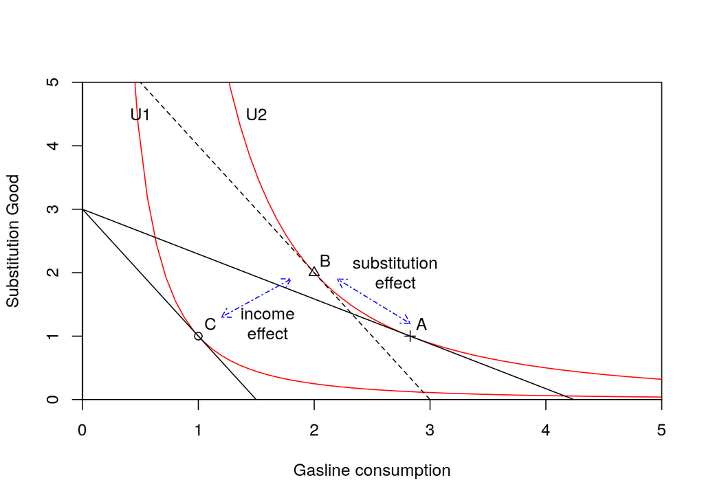

3. Wanting to increase the price of gasoline but not reduce economic welfare, suppose that, in addition to the $0.25 cent tax on gasoline, the government also provides consumers with an income tax rebate amounting to $16.7 billion dollars (total amount).
1. According to the estimation results above, what would be the effect of the gasoline tax and income tax policies on gasoline demand?

$$\widehat{\Delta G}=-18552.8*\Delta Pr+277.3*\Delta In=-18552.8\times0.25+277.3\times16.7 =-7.29$$

The result shows the effect of income tax policies offsets the effect of gasoline tax on gasoline demand. the gasoline consumption only decrease 7290 gallons.

2. According to economic theory, would the gasoline tax rise combined with the welfare-offsetting income tax rebate produce any reduction in the demand for gasoline?

The gasoline tax rise combined with the welfare-offsetting income tax rebate will not significently reduce the demand for gasoline. While the tax move the demand along the utility curve to left and change the slope of buget line, the income tax rebate will move the indifference curve to upper right. It negates the effect of policies.

3. Given your analysis in parts (i) and (ii), is it possible to implement a policy that is consistent with the goals of environmentalists and yet not reduce the economic welfare of consumers?

A possible policy is a selective distribution of the welfare. Instead of inincome tax rebate, the subsidise on transit which is a substitute good for auto trips. Based on the question 1, we knew that the low income group will be more elastic with the change of price. In this way the policy is consistent with the goals of environmentalists and does not reduce the economic welfare of low-income riders.

4. Calculate the income elasticity of demand, given that the sample mean for Income was $0.0011 billion dollars and gas demand was 0.35 thousand gallons.

$$\eta=\frac{\Delta Q/Q}{\Delta In_{}/In_{}}=\beta_2\frac{In_{}}{Q_{}}=277.3\frac{0.0011}{0.35}=0.8715143$$

the absolute value of income elasticity of demand is 0.8715143 that is less than 1. Each 1 percent increase of income makes 0.8715143% increase of demand. The gasoline consumption is inelastic for income.

3. Chicken or the egg

In class, we discussed the supply led and demand led views of transportation and economic development. There are nine major transportation projects listed below. While it is difficult to clearly define such projects as either demand led or supply led, some will display more characteristics of one or the other.

A. CrossRail – this project is to build two new railway connections under central London. CrossRail 1, approved in 2007, will run east-west and is due to open in 2018. It will complement Thameslink services, which commenced north-south rail services through the re-opened Snow Hill tunnel in 1989. B. Channel Tunnel – opened in 1995 and links Britain to France. C. M6 Toll motorway – The opening of this tollway around Birmingham, UK, in 2003 effectively provides a Birmingham by-pass and considerably reduced through journey times. D. Great Belt Link – opened in 1995 between the island of Zeeland and (in effect) the rest of Denmark, providing a road and rail link. E. Golden Gate Bridge – this bridge opened in 1937 across the San Francisco Bay, providing the first fixed link northwards out of San Francisco. F. Skye Bridge – this linked mainland Scotland to the island of Skye and was opened in 1995, originally with a highly controversial toll that was eventually abolished at the end of 2004. G. Mundra container terminal – this is the first container terminal at the port of Mundra on the Gujarat coast in northwest India, and started its operations in 2005. H. Jubilee line extension – this extension opened in 1999 and connected the London Underground system to then developing Docklands area in London I. WES Commuter Rail – this diesel-powered commuter rail service began operating in 2009, and extends rail service from Portland to Tigard, Tualatin and Wilsonville for the first time.

1. Categorize each of these projects into supply or demand led projects, and explain the reasons why you came to that particular view. Note that in many cases you do not need to know the specifics regarding the particular project to come to an educated guess, although some basic Googling of the locations that you are not familiar with might help with your guess.

| Supply led | CrossRail |  | M6 Toll motorway | Great Belt Link |  |  |  | Jubilee line extension |
| --- | --- | --- | --- | --- | --- | --- | --- | --- |
| Demand led |  | Channel Tunnel |  |  | Golden Gate Bridge | Skye Bridge | Mundra container terminal |  |

2. From the example projects listed, what overall conclusions can you draw regarding supply led and demand led transportation initiatives, particularly the balance between the two?

How to distinguish cause and effect? One answer is that causality is an asymmetric relation between cause and effect. In process philosophy, it needs to examine the process, event, becoming or happening to recognize the cause and every effect. Causal processes, which is more important than causal relationships or causal interactions, can be identified by their ability to transmit an alteration over space and time (Salmon, 1984). There are many theories such as probabilistic causation, causal calculus, structure learning, etc. (Hernán MA, 2019). Here we use time series as a simple way to infer their relation and process.

As many natural processes, The long economic cycles exhibit a progression from small beginnings that accelerates and approaches a climax over time, which synchronize with the diffusion of various innovations, infrastructures and energy source substitutions. It can be demonstrated by a logistic function or S-curve. For a given background including social, geographic and technology conditions, the x-axis is the time process and the y-axis represents the economic growth. If the transportation projects happened at the beginning or the end of the curve, the project is a relatively strong factor to the economy. We can say supply led transportation stimulates economic development. If the projects happened during the mid-segment of the curve, the project is a relatively weak factor and we would tend to use demand-led to explain this event.

My conclusion is that the value of slope $=1$ is two balance points which relate to some critical stages. When the slope is approaching 1, which means the project may leverage the economic development; when the slope is away from 1 to the inflection point, the project may Lags behind the economy and need ahead investment. After the inflection point, the project will have less and less stimulating effects. When the slope is away from 1 again and convergent to 0, the policy decision for a megaproject should be more conservative.

[figure not shown]

- Reference

*[1] Gibbs, M.N. (2000). Variational Gaussian process classifiers. IEEE Transactions on Neural Networks. 11 (6): 1458–1464.*

*[2] Hernán MA, Robins JM (2019). Causal Inference. Boca Raton: Chapman & Hall/CRC, forthcoming.*

*[3] Mackie, John L. The Cement of the Universe: A study in Causation. Clarendon Press, Oxford, England, 1988.*

*[4] Salmon, W. (1984) Scientific Explanation and the Causal Structure of the World. Princeton University Press.*

## Problem Set 3

1. Using the Logit Model

$V_{auto}=-0.05-0.08TT_{auto}-0.105Cost_{parking}+0.00001Income_{HH}$

$V_{bus}=-0.08TT_{bus}-0.10WT_{bus}-0.65Fare_{bus}$

where $V_{auto}$ and $V_{bus}$ are the systematic utilities of auto and bus respectively; $TT_{auto}$ is the travel time for mode (in minutes); $Income_{HH}$ is the household annual income (in dollars); $Cost_{parking}$ and $Fare_{bus}$ are in dollars; $TT_{bus}$ is the travel time for the bus (in minutes); $WT_{bus}$is the waiting time for bus (in minutes). For simplicity let’s assume average waiting time to be half the headway.

|  | Segment | A | Segment | B |
| --- | --- | --- | --- | --- |
| Variable | Auto | Bus | Auto | Bus |
| Auto Travel time(min) | 25 | - | 40 | - |
| Parking cost($) | 3.00 | - | 8.00 | - |
| Bus Travel time(min) | - | 40 | - | 60 |
| Bus headway(min) | - | 15 | - | 20 |
| Household annual income($) |  | 40000 |  | 80000 |

1. Based on the information in Table 1, compute the probabilities that an individual belonging to each segment will choose auto for a work trip.

$V_{auto}=\begin{cases}-0.05-0.08\times25-0.105\times3.00+0.00001\times40000=-1.965 & \text{Segment A} \\-0.05-0.08\times40-0.105\times8.00+0.00001\times80000=-3.29 & \text{Segment B} \end{cases}$

$V_{bus}=\begin{cases}-0.08\times40-0.10\times\frac{15}2-0.65\times0.85=-4.5025 & \text{Segment A} \\-0.08\times60-0.10\times\frac{20}2-0.65\times2.00=-7.1 & \text{Segment B} \end{cases}$

$P_{auto}=\frac{\mathrm{e}^{V_{auto}}}{\mathrm{e}^{V_{auto}}+\mathrm{e}^{V_{bus}}}=\begin{cases} \frac{\mathrm{e}^{-1.965}}{\mathrm{e}^{-1.965}+\mathrm{e}^{-4.5025}}=0.9267293=92.67293\% & \text{Segment A} \\\frac{\mathrm{e}^{-3.29}}{\mathrm{e}^{-3.29}+\mathrm{e}^{-7.1}}=0.9783317=97.83317\%& \text{Segment B} \end{cases}$

The probabilities of choosing auto for a work trip for an individual belonging to segment A is 92.67293%. That of segment B is 97.83317%.

2. In order to increase transit ridership, the local transport authority is considering the following options:
3. Reducing the fare by 50 cents in both segments.

$V'_{bus}=\begin{cases}-0.08\times40-0.10\times\frac{15}2-0.65\times(0.85-0.50)=-4.1775 & \text{Segment A} \\-0.08\times60-0.10\times\frac{20}2-0.65\times(2.00-0.50)=-6.775 & \text{Segment B} \end{cases}$

$P'_{bus}=\frac{\mathrm{e}^{V'_{bus}}}{\mathrm{e}^{V_{auto}}+\mathrm{e}^{V'_{bus}}}=\begin{cases} \frac{\mathrm{e}^{-4.1775}}{\mathrm{e}^{-1.965}+\mathrm{e}^{-4.1775}}=0.09863359=9.863359\% & \text{Segment A} \\\frac{\mathrm{e}^{-6.775}}{\mathrm{e}^{-3.29}+\mathrm{e}^{-6.775}}=0.02974205=2.974205\%& \text{Segment B} \end{cases}$

$\Delta P_{bus}=P'_{bus}-(1-P_{auto})=\begin{cases} 9.863359\%-(1-92.67293\%)=2.536289\% & \text{Segment A} \\2.974205\%-(1-97.83317\%)=0.807375\% & \text{Segment B} \end{cases}$

$\frac{\Delta P_{busA}}{\Delta P_{busB}}=\frac{2.536289\%}{0.807375\%}=3.141401$

2. Doubling the number of buses on each route (which would halve the headways).

$V''_{bus}=\begin{cases}-0.08\times40-0.10\times\frac{15}4-0.65\times0.85=-4.1275 & \text{Segment A} \\-0.08\times60-0.10\times\frac{20}4-0.65\times2.00=-6.6 & \text{Segment B} \end{cases}$

$P''_{bus}=\frac{\mathrm{e}^{V''_{bus}}}{\mathrm{e}^{V_{auto}}+\mathrm{e}^{V''_{bus}}}=\begin{cases} \frac{\mathrm{e}^{-4.1275}}{\mathrm{e}^{-1.965}+\mathrm{e}^{-4.1275}}=0.1031689=10.31689\% & \text{Segment A} \\\frac{\mathrm{e}^{-6.6}}{\mathrm{e}^{-3.29}+\mathrm{e}^{-6.6}}=0.03522972=3.522972\%& \text{Segment B} \end{cases}$

$\frac{\Delta P_{busA}}{\Delta P_{busB}}=\frac{2.98982\%}{1.356142\%}=2.204651$

3. Increasing parking costs by 50% (i.e. $3.00 parking cost increases to $4.50) For each population segment, how will each of these strategies affect transit ridership (market share of transit), and which option will be most effective in increasing ridership?

$V'_{auto}=\begin{cases}-0.05-0.08\times25-0.105\times3.00\times1.5+0.00001\times40000=-2.1225 & \text{Segment A} \\-0.05-0.08\times40-0.105\times8.00\times1.5+0.00001\times80000=-3.71 & \text{Segment B} \end{cases}$

$P'_{auto}=\frac{\mathrm{e}^{V'_{auto}}}{\mathrm{e}^{V'_{auto}}+\mathrm{e}^{V_{bus}}}=\begin{cases} \frac{\mathrm{e}^{-2.1225}}{\mathrm{e}^{-2.1225}+\mathrm{e}^{-4.5025}}=0.9152894=91.52894\% & \text{Segment A} \\\frac{\mathrm{e}^{-3.71}}{\mathrm{e}^{-3.71}+\mathrm{e}^{-7.1}}=0.9673905=96.73905\%& \text{Segment B} \end{cases}$

$\Delta P_{bus}=-\Delta P_{auto}=P_{auto}-P'_{auto}=\begin{cases} 92.67293\%-91.52894\%=1.14399\% & \text{Segment A} \\97.83317\%-96.73905\%=1.09412\% & \text{Segment B} \end{cases}$

$\frac{\Delta P_{busA}}{\Delta P_{busB}}=\frac{1.14399\%}{1.09412\%}=1.04558$

Based on the results, all of the options can increase market share of transit in both segment A and B. Comparing the three $\Delta P_{bus}$, doubling the number of buses on each route is most effective in increasing ridership for both segments. It is hard to say which option is best because the cost of each option is unknown.

In this case, we can find the spatial difference of the effects between segement A and B, which may be called “location elasticity”. $\frac{\Delta P_{busA}}{\Delta P_{busB}}=3.141401$ shows reducing fare in city center is much more effective than in suburb. $\frac{\Delta P_{busA}}{\Delta P_{busB}}=2.204651$ also proves doubling the number of buses in city center is better than in subrub. Meanwhile, there is not significant difference of effect between segement A and B for increasing parking costs ($\frac{\Delta P_{busA}}{\Delta P_{busB}}=1.04558$).

3. Describe, using a few sentences, another policy that can be analyzed using this demand model.

According to the model, other possible policies include changing the travel time or changing the purchasing power of transit. Setting bus lanes can decrease the bus travel time. Providing discount bus tickets can drop the real bus fare while income stays same. Both of the policies can increase the transit share.

4. What monetary value of bus travel time, measured in dollars per hour, is implied by the coefficients of this model?

$VOT =\frac{\frac{\Delta V_{bus}}{\Delta TT_{bus}}}{\frac{\Delta V_{bus}}{\Delta Fare_{bus}}}=\frac{-0.08}{-0.65}\times60=7.384615$ $/hour

In this model, bus fare instead of $\frac{cost}{wage}$ measures the systematic utilities per dollar. The monetary value of bus travel time is 7.384615 $/hour.

2. Transportation and Land Use

To examine the relationship between transportation cost and land use, consider the following example. A region produces coffee, tea, and wheat for world markets. All output is sold at the port for the current price. Assume that the only input is land and that each farmer gets to keep the price minus the transportation cost and must also pay rent on the land.

|  | Coffee | Tea | Wheat |
| --- | --- | --- | --- |
| Acres of land per unit of output | 0.2 | 0.25 | 0.5 |
| Transport cost per unit per mile | 8 | 5 | 1 |
| Price at the port | 100 | 100 | 100 |

1. In a competitive market, what is the land rent at each distance from the port? At what distance is each crop grown? (Specify the bid rent equation for each crop and the distances over which each will be highest. The latter part can be seen most easily by graphing the equations, but the distances should be calculated directly from the equations.)

Let $S$ is the land area for each crop. $R_{coffee}S=\frac{S}{0.2}P-\frac{S}{0.2}\cdot8D\implies$

$$\begin{cases}R_{coffee}=\frac{100}{0.2}-\frac{8D}{0.2}=500-40D& D\in[0,12.5]\\
R_{tea}=\frac{100}{0.25}-\frac{5D}{0.25}=400-20D& D\in[0,20]\\
R_{wheat}=\frac{100}{0.5}-\frac{1D}{0.5}=200-2D& D\in[0,100]
\end{cases}$$

From the bid-rent theory, only one type of land use with highest rent dominates the land for any distance.

suppose $R_{coffee}\ge R_{tea}$, then $500-40D\ge 400-20D\implies D\le5$,

suppose $R_{tea}\ge R_{wheat}$, then $400-20D\ge 200-2D\implies D\le11.11111$

Therefore, coffee lands dominate the distance with the port from 0 to 5 miles; tea lands dominate the distance with the port from 5 to 11.11 miles; wheat lands dominate the distance with the port from 11.11 to 100 miles.

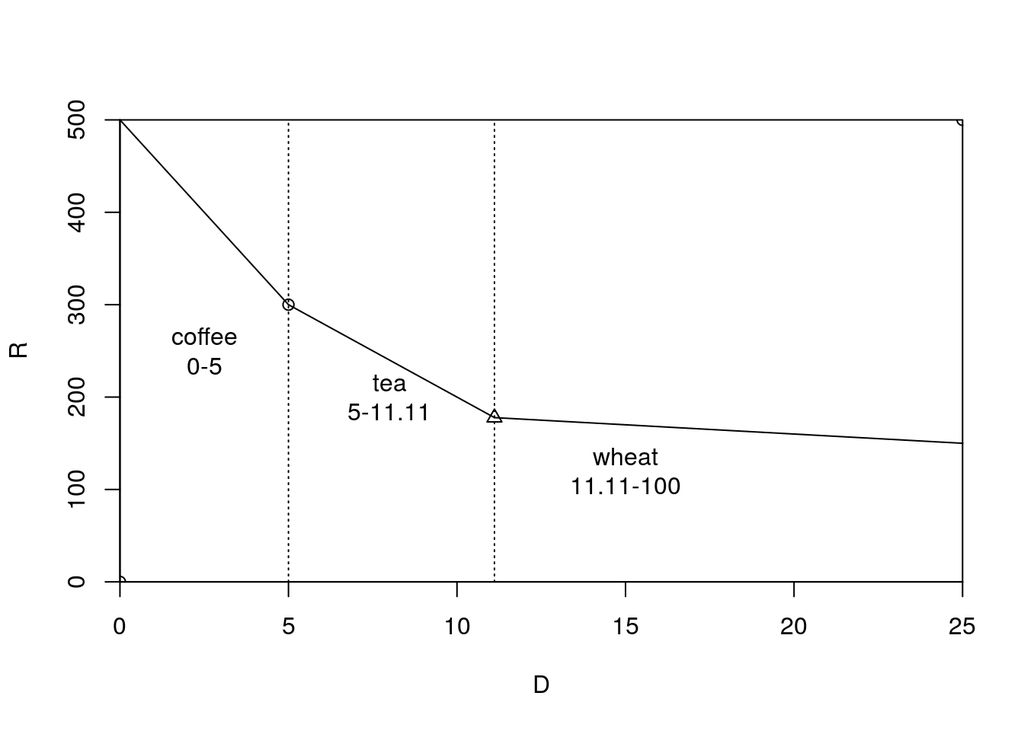

2. Land Owner owns 100 acres of land 15 miles from the port. What is the annual rental income? If the interest rate is 5% per year and all prices and costs are expected to remain the same forever, what is the market value of the land?

For wheat is grown in the land 15 miles from the port, then

$R_{wheat}S=(200-2\times15)\times100=\$17000$

$MV=\frac{SR_{wheat}}i=\frac{\$17000}{0.05}=\$340000$

3. Return to the assumptions of (a) but assume that the government decides to subsidize 50% of all transport costs. What happens to land rents and the distance each crop is grown? What would you conclude regarding the impact of transportation costs on city size? What is Land Owners’ land worth now if the interest rate is 5%? Are the farmers any better off because of the subsidy? Who does benefit from the subsidy?

$$\begin{cases}R'_{coffee}=\frac{100}{0.2}-\frac{8D}{0.2\times2}=500-20D'& D'\in[0,25]\\
R'_{tea}=\frac{100}{0.25}-\frac{5D}{0.25\times2}=400-10D'& D'\in[0,40]\\
R'_{wheat}=\frac{100}{0.5}-\frac{1D}{0.5\times2}=200-D'& D'\in[0,200]
\end{cases}$$

For given $D$ is positive, $R'>R$ , the rents will be higher than before. For the same rents, $D'=2D$, the coffee lands dominate the distance with the port from 0 to 10 miles; tea lands dominate the distance with the port from 10 to 22.22 miles; wheat lands dominate the distance with the port from 22.22 to 200 miles. We get to know that lower transportation cost results in larger city size.

After subsidy, tea is grown in the land 15 miles from the port, then $MV'=\frac{(400-10\times15)\times100}{0.05}=\$500000$.

The results show that the subsidy will transfer to the land value. The farmers have to pay more rent. Only the land owners can benefit from the subsidy.

4. What happens in (c) if all prices for output fall by 50% as well?

$$\begin{cases}R''_{coffee}=\frac{100}{0.2\times2}-\frac{8D}{0.2\times2}=250-20D& D\in[0,12.5]\\
R''_{tea}=\frac{100}{0.25\times2}-\frac{5D}{0.25\times2}=200-10D& D\in[0,20]\\
R''_{wheat}=\frac{100}{0.5\times2}-\frac{1D}{0.5\times2}=100-D& D\in[0,100]
\end{cases}$$

The results show that the proportional changes of rent result same land use distribution as the beginning. Wheat is grown in the land 15 miles from the port, $R''=\frac12R=\$8500$, $MV''=\frac12MV=\$170000$.

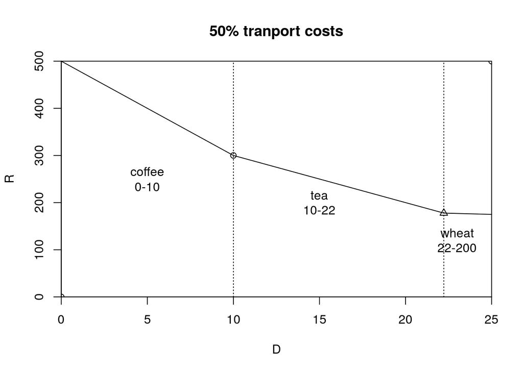

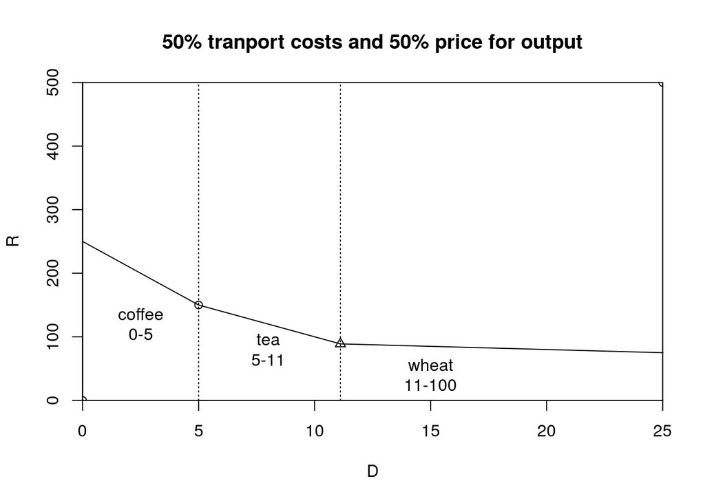

5. Describe the potential impacts on land use if investments were made to the transportation infrastructure (increasing highway lanes) such that transportation costs are lowered.

The impacts on land use by transportation infrastructure are similar to that by a subsidy on transport costs. The land area for each crop will expand. The rents will be higher. The city size will be larger. The land owners will benifit from the investements. The difference is these impacts are not even. For example, the lands are closer to highway exits will be more like to change the land use to high output industries with higher rent and land value. The new transportation infrastructure changes the time distance for different locations, which will twist the pattern of concentric rings of land use from the bid-rent model.